# Random Variables, Propagation, and Shared Physics

COMP 521 · Block 6 · Guide Lectures 1–2

COMP 521 · PROBABILITY, OPTIMIZATION, AND SCIENTIFIC DISCOVERY

## Random variables, propagation, and shared physics

How does uncertainty in a physical model’s inputs reach its predictions?

$$\boldsymbol\Theta\sim p(\boldsymbol\theta)
\quad\longrightarrow\quad
\mathbf Y=\mathcal G(\boldsymbol\Theta)
\quad\longrightarrow\quad p(\mathbf y).$$

Anna Rosen · San Diego State University

THE STATE OF PHYSICS AND THE STATE OF KNOWLEDGE

## Deterministic physics, uncertain inputs

### The physical model

$$\mathbf y=\mathcal G(M,Z,t,\boldsymbol\phi).$$

- $M$: initial mass; $Z$: metallicity.
- $t$: age; $\boldsymbol\phi$: other physics parameters.
- Fixed inputs and algorithm give a fixed prediction, up to numerical error.

### Our information

Uncertain inputs are represented by a **distribution of possible inputs**.

Different plausible inputs produce different predictions through the same model.

Probability can describe missing knowledge as well as variation between objects.

DEFINE THE OBJECT BEFORE USING ITS DISTRIBUTION

## A random variable is a rule; a realization is a value

$$X:\Omega\longrightarrow\mathbb R.$$

- **Sample space $\Omega$:** the possible outcomes in the probability model.
- **Random variable $X$:** a rule assigning a number to each outcome.
- **Realization $x$:** one value obtained from that rule.

Example: $X=M/M_\odot$ is the uncertain mass in solar units. A draw might give $x=1.03$.

Uppercase letters denote random variables; lowercase letters denote their values.

DIFFERENT SOURCES REQUIRE DIFFERENT RESPONSES

## Identify what creates the uncertainty

### Variability

**Aleatoric:** variation under a fixed model and conditioning information.

A different star or a repeated exposure can give a different outcome.

Model and sample the variability.

### Missing knowledge

**Epistemic:** uncertainty about a parameter or model.

A shared calibration or opacity law may be uncertain.

Informative data can constrain an identifiable parameter.

### Numerical error

An unconverged solver or incorrect derivative is a computational error.

It is not automatically random noise with a known distribution.

Check convergence, references, and the implementation.

A PROBABILITY MASS FUNCTION

## Discrete probability assigns weight to outcomes

A **discrete random variable** takes values in a countable set.

| Illustrative category $c$ | $P(C=c)$ |
| --- | --- |
| White dwarf | 0.70 |
| Neutron star | 0.20 |
| Black hole | 0.10 |

$$\sum_c P(C=c)=1.$$

These are teaching probabilities, not a measured remnant population.

Predict

Does density height give the probability of one exact mass?

Explain

A point has probability zero for a continuous density. An interval’s probability is its area under the curve.

PDF, CDF, AND QUANTILES

## A density gives areas; a CDF gives accumulated probability

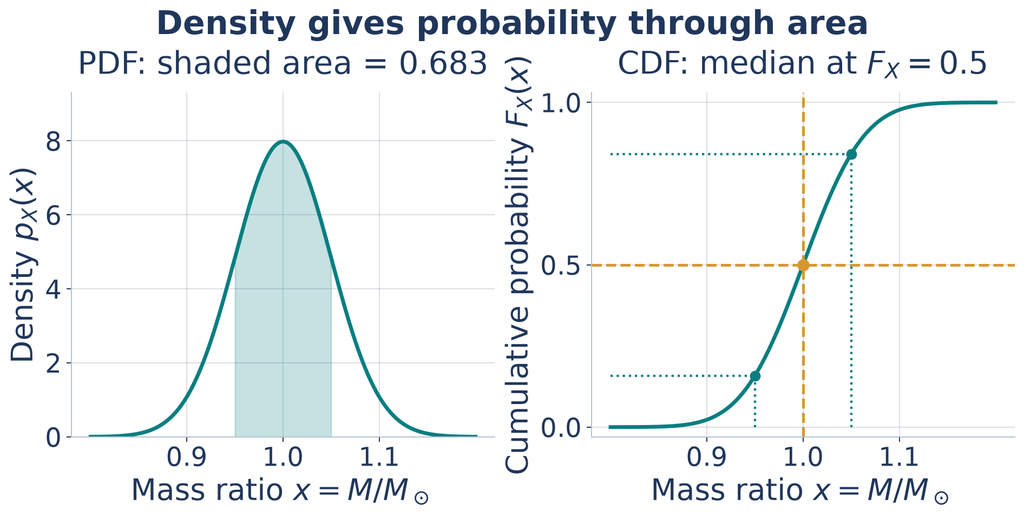

**PDF:** probability density function $p_X$.

$$P(a\le X\le b)=\int_a^b p_X(x)\,dx.$$

**CDF:** cumulative distribution function.

$$F_X(x)=P(X\le x).$$

A **quantile** $x_q$ satisfies $F_X(x_q)=q$ when the CDF is continuous and increasing.

Density has inverse units of its input. Here $X=M/M_\odot$ is dimensionless.

MOMENTS OF A DISTRIBUTION

## Mean, variance, and standard deviation describe different features

**Expectation or mean:** the probability-weighted average.

$$\mu_X=\mathbb E[X]=\int x\,p_X(x)\,dx.$$

**Variance:** the mean squared distance from the mean.

$$\operatorname{Var}(X)=\mathbb E[(X-\mu_X)^2].$$

**Standard deviation:** the square root of the variance, in the units of $X$.

$$\sigma_X=\sqrt{\operatorname{Var}(X)}.$$

THE LAW OF THE UNCONSCIOUS STATISTICIAN

## Average the model without deriving the output density

$$\mathbb E[g(X)]=\int g(x)\,p_X(x)\,dx.$$

### What is being averaged?

- $g(x)$ is the model prediction at input $x$.
- $p_X(x)\,dx$ supplies its probability weight.
- Average **predictions across inputs**.

### What does this avoid?

You can compute the mean of $Y=g(X)$ without first finding a formula for $p_Y(y)$.

Monte Carlo replaces this weighted integral with an average of sampled predictions.

KEEP THE CONDITIONING INFORMATION VISIBLE

## Joint, marginal, and conditional probability

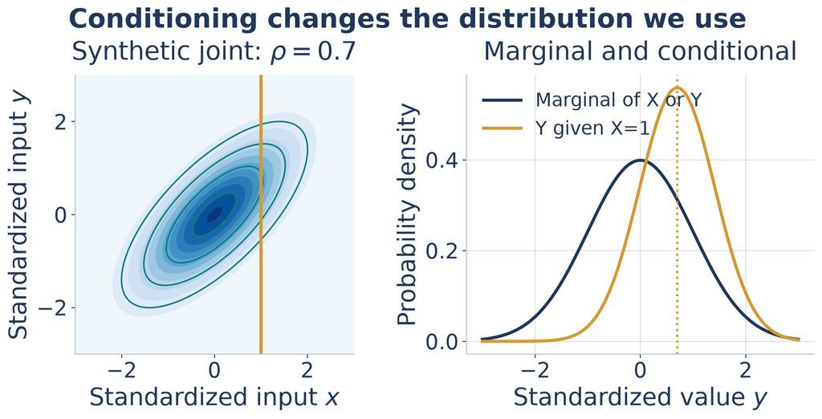

- **Joint** $p(x,y)$: combinations of values.
- **Marginal:** integrate out the coordinate you do not retain.
- **Conditional** $p(y\mid x)$: fix $x$ and normalize the slice.

$$p(y\mid x)=\frac{p(x,y)}{p(x)},\qquad p(x)>0.$$

These are synthetic standardized coordinates.

DEPENDENCE IS PART OF THE INPUT MODEL

## Covariance records how deviations occur together

$$\operatorname{Cov}(X_1,X_2)
=\mathbb E[(X_1-\mu_1)(X_2-\mu_2)].$$

- **Positive covariance:** same-sign deviations tend to occur together.
- **Negative covariance:** opposite-sign deviations tend to occur together.
- **Correlation** rescales covariance: $\rho=\operatorname{Cov}(X_1,X_2)/(\sigma_1\sigma_2)$.

The **covariance matrix** collects variances on its diagonal and covariances elsewhere:

$$\Sigma_X=\begin{pmatrix}
\sigma_1^2 & \rho\sigma_1\sigma_2\\
\rho\sigma_1\sigma_2 & \sigma_2^2
\end{pmatrix}.$$

Zero covariance alone does not imply independence.

ACCOUNT FOR THE STRETCH OF THE COORDINATE

## A change of variables preserves probability, not density height

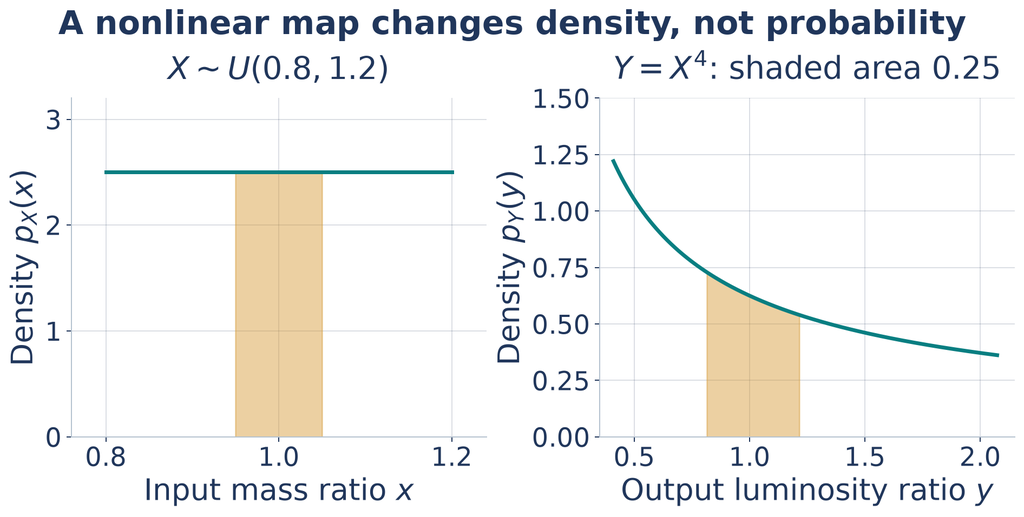

Smooth invertible map on positive inputs. The inverse derivative corrects interval stretching.

$$p_Y(y)=p_X\!\left(g^{-1}(y)\right)
\left|\frac{d g^{-1}(y)}{dy}\right|.$$

The **inverse map** $g^{-1}$ returns the input corresponding to an output.

A MATRIX OF FIRST DERIVATIVES

## A Jacobian describes local stretching in several dimensions

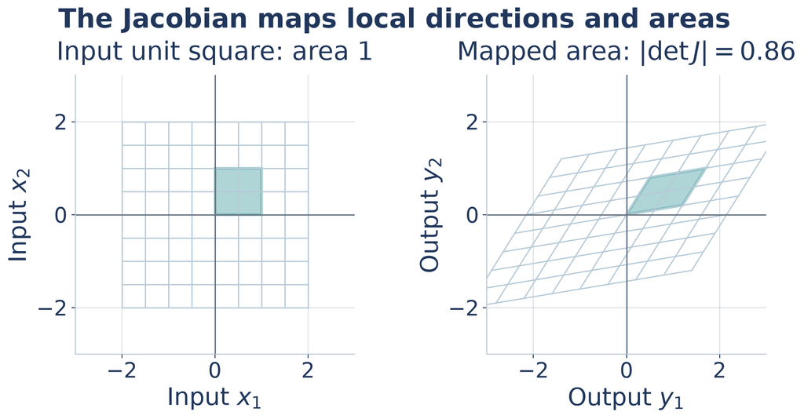

$$J_{ij}=\frac{\partial y_i}{\partial\theta_j}.$$

$J_{ij}$ measures how output $i$ responds to input $j$ locally.

The **determinant** gives the signed local volume factor. Density uses its absolute value.

For a smooth invertible equal-dimensional map,

$$p_Y(\mathcal G(\boldsymbol\theta))
=\frac{p_\Theta(\boldsymbol\theta)}{|\det J|}.$$

ONE MODEL, MANY PLAUSIBLE INPUTS

## The pushforward is the distribution of mapped inputs

$$\boldsymbol\Theta^{(i)}\sim p(\boldsymbol\theta)
\quad\longrightarrow\quad
\mathbf Y^{(i)}=\mathcal G(\boldsymbol\Theta^{(i)}).$$

The **pushforward distribution** describes these output values and their probabilities.

We often need its mean and covariance rather than a closed-form density.

| Strategy | Main idea |
| --- | --- |
| Monte Carlo | Sample inputs and evaluate the full model. |
| First-order delta method | Approximate the model locally by its tangent. |
| Second-order delta method | Add the leading effect of curvature. |

AN EXPLICIT LOCAL TEACHING MODEL

## One worked example: uncertain mass, uncertain luminosity

Define dimensionless mass and luminosity:

$$X=\frac{M}{M_\odot},\qquad Y=\frac{L}{L_\odot}=g(X)=X^4.$$

Let

$$X\sim\mathcal N(1,0.05^2).$$

- $\mathcal N(\mu,\sigma^2)$ denotes a Gaussian with mean $\mu$ and variance $\sigma^2$.
- The input mean is $1\,M_\odot$ and its standard deviation is $0.05\,M_\odot$.
- The fourth-power relation is a local approximation for teaching, not a universal stellar law.

The Gaussian is also a local approximation. Zero mass is 20 standard deviations below its mean.

MONTE CARLO PROPAGATION

## Strategy 1: send sampled inputs through the full model

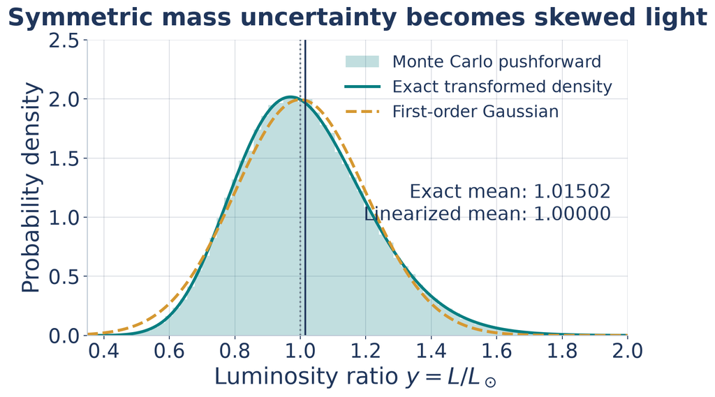

Synthetic outputs from the local fourth-power teaching model.

For independent draws $x_i$, estimate $\bar y=N^{-1}\sum_i g(x_i)$.

**Executed result:** $1.01521\pm0.00045$ (MC standard error; 200,000 draws).

REPARAMETERIZATION: FIX THE NOISE, CHANGE THE INPUT MODEL

## Separate a distribution’s parameters from its random draws

$$X=\mu+\sigma\epsilon,$$

$$\epsilon\sim\mathcal N(0,1).$$

Draw standard-normal noise once. Scaling and shifting give draws with the desired mean and standard deviation.

Keep the same noise when comparing nearby parameter values.

Reuse one set of standard-normal draws

```python
import numpy as np

rng = np.random.default_rng(20261105)
eps = rng.normal(size=200_000)
sigma = 0.05

def mean_luminosity(mu):
    x = mu + sigma * eps
    return np.mean(x**4)
```

This is a deterministic function of `mu` once `eps` is fixed. Differentiating it is a later topic.

STANDARD DEVIATION VERSUS STANDARD ERROR

## Output spread and Monte Carlo error are different quantities

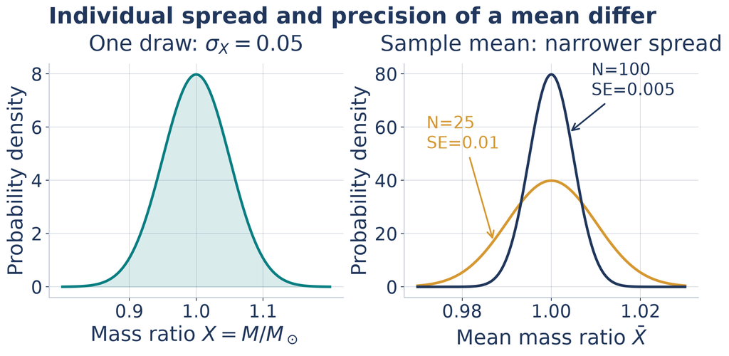

**Standard deviation** $\sigma_Y$: spread of individual model outputs.

**Standard error** of their mean:

$$\operatorname{SE}(\bar Y)=\frac{\sigma_Y}{\sqrt N}.$$

For independent, identically distributed draws with finite variance, estimate this with $s_Y/\sqrt N$.

More draws improve the estimated mean. They do not narrow the modeled population.

FIRST-ORDER DELTA METHOD

## Strategy 2: use the local tangent

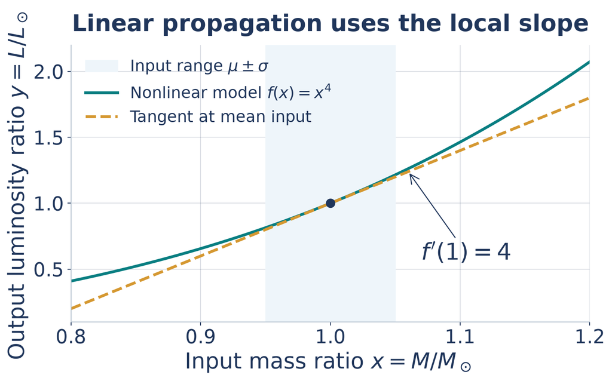

$$\begin{aligned}g(X)&\approx g(\mu)\\
&\quad+g'(\mu)(X-\mu).\end{aligned}$$

- $\mu=\mathbb E[X]$ is the expansion point.
- $g'(\mu)$ is the local slope or **sensitivity**.

$$\mathbb E[Y]\approx g(\mu),$$

$$\sigma_Y\approx |g'(\mu)|\sigma_X.$$

This works when the map is nearly linear across the input distribution’s width.

WORK THE PROPAGATION BEFORE TRUSTING THE FORMULA

## How much does luminosity uncertainty grow?

Worked example

1 · Differentiate the model

$$g(x)=x^4,\qquad g'(x)=4x^3,\qquad g'(1)=4.$$

2 · Multiply the input spread by the local sensitivity

$$\sigma_Y\approx 4(0.05)=0.20.$$

3 · Express the result as relative uncertainty

$$\frac{\sigma_L}{L}\approx
\left|\frac{d\ln L}{d\ln M}\right|\frac{\sigma_M}{M}
=4(5\%)=20\%.$$

This is a first-order approximation evaluated at the mean input.

THE JACOBIAN SANDWICH

## In several dimensions, propagate the whole covariance matrix

$$\delta\mathbf Y\approx J\,\delta\boldsymbol\Theta
\quad\Longrightarrow\quad
\Sigma_Y\approx J\Sigma_\Theta J^{\mathsf T}.$$

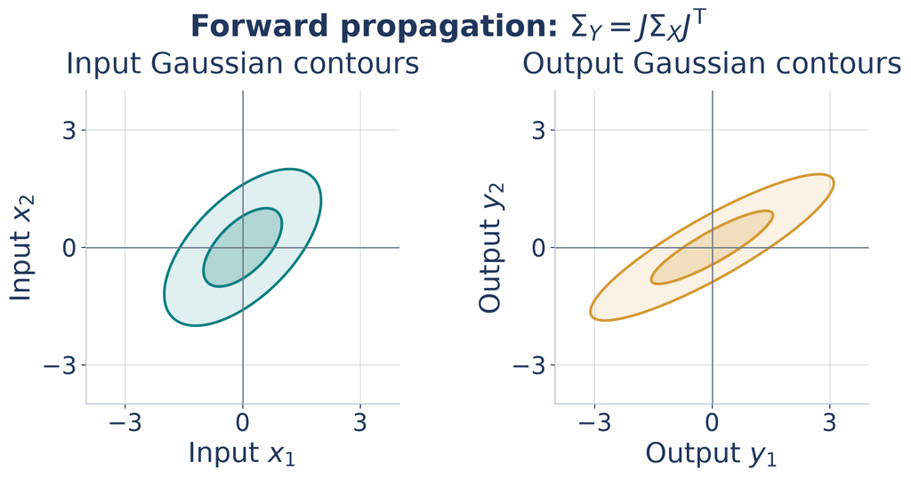

- $J$: local output sensitivities.
- $\Sigma_\Theta$: input variances and covariances.
- $J^{\mathsf T}$: **transpose**, which swaps rows and columns; it is not an inverse map.

The covariance identity is exact for a linear map with finite second moments. For a nonlinear map, it is local.

PREDICT BEFORE REVEALING THE CORRECTION

## Curvature changes the mean prediction

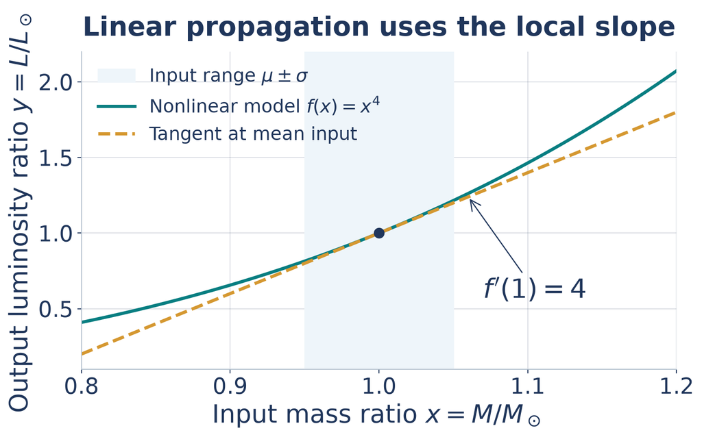

The **convex** fourth-power curve lies above its tangents.

Predict

Is $\mathbb E[X^4]$ above, below, or equal to $(\mathbb E[X])^4$?

Explain

Above here. Jensen’s inequality gives

$$\mathbb E[g(X)]\ge g(\mathbb E[X])$$

for convex $g$. The inequality reverses for concave $g$.

SECOND-ORDER DELTA METHOD

## Strategy 3: correct the leading effect of curvature

### One uncertain input

$$\mathbb E[g(X)]\approx
g(\mu)+\tfrac12 g''(\mu)\sigma_X^2.$$

$g''$ is the **second derivative**, measuring curvature.

For $g(x)=x^4$ at $\mu=1$,

$$1+\tfrac12(12)(0.05^2)=1.015.$$

The exact mean is 1.01501875. Higher-order terms remain.

### Several inputs, one scalar output

$$\begin{aligned}\mathbb E[g(\boldsymbol\Theta)]&\approx g(\boldsymbol\mu)\\
&\quad+\tfrac12\operatorname{tr}(H_g\Sigma_\Theta).\end{aligned}$$

- **Hessian** $H_g$: matrix of second partial derivatives of $g$.
- **Trace** $\operatorname{tr}$: sum of a matrix’s diagonal entries.
- $\Sigma_\Theta$: input covariance matrix.

Higher-order terms remain.

COMPARE AGAINST THE SAME INPUT MODEL

## Choose an evaluator by its assumptions and the needed accuracy

| Method | Mean in this example | Spread | Main limitation |
| --- | --- | --- | --- |
| Monte Carlo | $1.01521\pm0.00045$ (SE) | Sample distribution | Finite draws can miss rare regimes. |
| First order | $g(\mu)=1$ | Jacobian propagation | Misses curvature and regime changes. |
| Second order | 1.015 | Additional approximation | Neglected higher-order terms. |

Exact mean: 1.01501875.

An **affine map** is a linear map plus a constant offset. First-order propagation is exact for such a map.

WHEN LINEARIZATION BREAKS DOWN

## A local derivative cannot describe an unseen branch

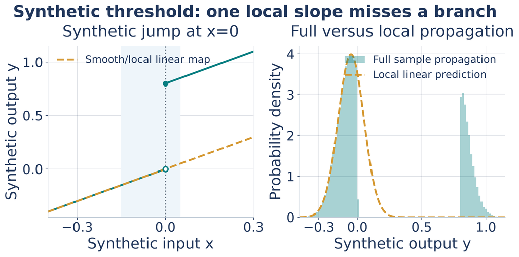

A distribution can span a qualitative transition even when a derivative exists at its mean.

Stellar examples include changes of ignition regime or remnant outcome. This figure is a synthetic example, not a physical transition-mass calibration.

TARGETED ENSEMBLES NEAR KNOWN BOUNDARIES

## Check the approximation where the model changes behavior

Worked example

1 · Locate the relevant regime boundary

Can plausible inputs reach both sides of the boundary?

2 · Evaluate the full model across that range

Use a targeted ensemble with explicit input probabilities or weights.

3 · Compare the quantities you intend to report

Compare means, spread, and regime probabilities. A mean can hide a branch.

Check sampling error and coverage of rare regimes.

DRAW A SHARED PARAMETER ONCE FOR THE WHOLE COHORT

## Independent scatter and shared physics affect a cohort differently

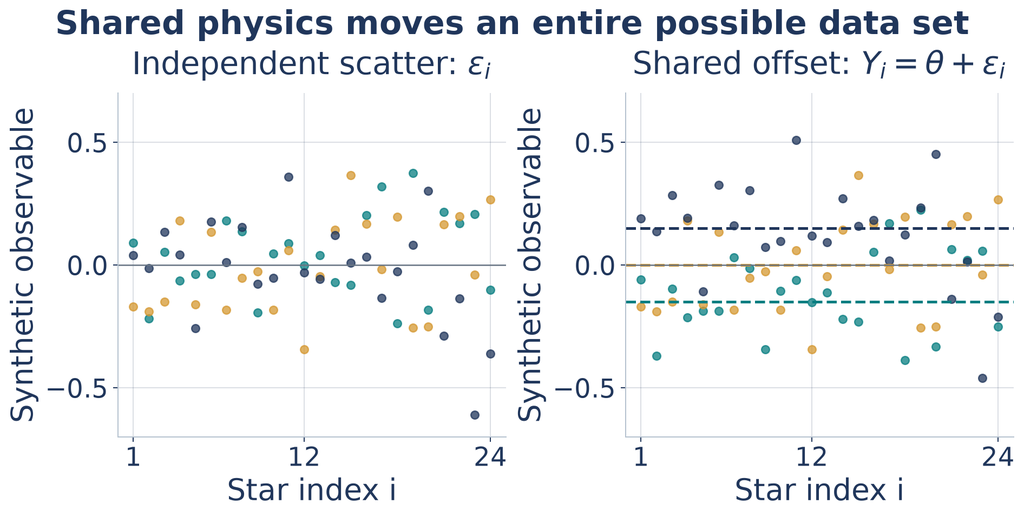

Colors identify cohorts. Right-panel offsets are −0.15, 0, and 0.15; identical residuals are reused.

$$Y_i=\theta+\epsilon_i.$$

Shared offset: $\operatorname{Var}(\theta)=\sigma_\theta^2$. Independent zero-mean residuals: $\operatorname{Var}(\epsilon_i)=\sigma_\epsilon^2$. Residuals are independent of $\theta$.

FIRST ASK WHICH RANDOM QUANTITY THE VARIANCE DESCRIBES

## Total variance separates within-model and between-model spread

$$\begin{aligned}\operatorname{Var}(Y)
&=\mathbb E_\theta[\operatorname{Var}(Y\mid\theta)]\\
&\quad+\operatorname{Var}_\theta(\mathbb E[Y\mid\theta]).\end{aligned}$$

- $Y\mid\theta$ means: hold the shared physics fixed.
- $\mathbb E_\theta$ and $\operatorname{Var}_\theta$ average or measure spread over the uncertain shared parameter.
- This identity concerns the specified $Y$. For one object, it does not contain a sample-size factor.

In the additive model,

$$\operatorname{Var}(Y_i)=\sigma_\epsilon^2+\sigma_\theta^2.$$

THE QUANTITY BEING AVERAGED MUST BE NAMED

## Apply total variance to the cohort mean

$$\bar Y=\frac1N\sum_{i=1}^N Y_i
=\theta+\frac1N\sum_{i=1}^N\epsilon_i.$$

Worked example

At fixed shared offset

$$\mathbb E[\bar Y\mid\theta]=\theta,\qquad
\operatorname{Var}(\bar Y\mid\theta)=\frac{\sigma_\epsilon^2}{N}.$$

Across uncertain shared offsets

$$\operatorname{Var}(\bar Y)
=\frac{\sigma_\epsilon^2}{N}+\sigma_\theta^2.$$

The independent part averages down. The shared contribution remains while its uncertainty is held fixed.

PREDICTIVE UNCERTAINTY WITH FIXED SHARED-PARAMETER UNCERTAINTY

## An unconstrained shared offset does not average away

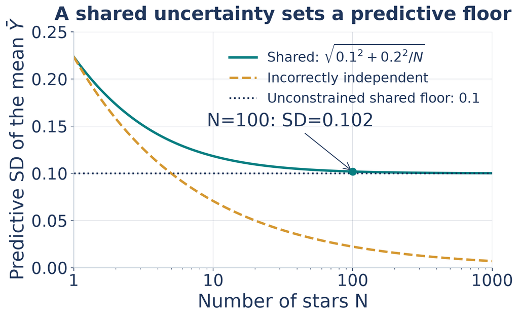

For $\sigma_\theta=0.1$, $\sigma_\epsilon=0.2$, and $N=100$:

$$\operatorname{sd}(\bar Y)=\sqrt{0.0104}\approx0.102.$$

Treating everything as independent would give about 0.022.

**More informative kinds of data** can constrain an identifiable $\theta$. This floor is conditional on leaving its uncertainty fixed.

LECTURES 1–2 · RETRIEVE, EXPLAIN, THEN CHECK

## What should survive the calculation?

Explain to a partner

1. What is preserved under a coordinate change?
2. How can curvature shift a mean prediction?
3. Which term resists averaging in our shared-offset model?

Explain

1. **Probability** in corresponding regions.
2. **Curvature** changes the average prediction.
3. **Shared variance** $\sigma_\theta^2$, while it stays fixed.

Reading: guide Lecture 1, Sections 1.1–1.5; Lecture 2, Sections 1.6–1.7.